# Exploring GapMinder Data

setwd(“~/Udacity/dataAnalysisR/EDA_R_Udacity/lesson3”)

# Investigating gapminder data

```r
# The Gapminder website contains over 500 data sets with information about
# the world's population. Your task is to download a data set of your choice
# and create 2-5 plots that make use of the techniques from Lesson 3.

# You might use a simple histogram, a boxplot split over a categorical variable,
# or a frequency polygon. The choice is yours!

# You can find a link to the Gapminder website in the Instructor Notes.

# Once you've completed your investigation, create a post in the discussions that includes:
#       1. any questions you answered, your observations, and summary statistics
#       2. snippets of code that created the plots
#       3. links to the images of your plots

# You can save images by using the ggsave() command.
# ggsave() will save the last plot created.
# For example...
#                  qplot(x = price, data = diamonds)
#                  ggsave('priceHistogram.png')


# ggsave currently recognises the extensions eps/ps, tex (pictex),
# pdf, jpeg, tiff, png, bmp, svg and wmf (windows only).

# Copy and paste all of the code that you used for
# your investigation, and submit it when you are ready.
# ====================================================================================
```

## Load Libraries

```r
library(ggplot2)
library(ggthemes)
library(gridExtra)
```

## Clean Data

Data was in wide format (each row is country each column is year) with missing values and less than intuitive columns names. I cleaned this up using PANDAS in the followiing way.

-Renamed first column country -Transposed data so that countries are in columns and year in row -replaced nan values with mean of each column (in this case country working hours) -Transposed back to original form -melted so that data is in long form (country, year, hours)

## Read Data

```r
workhours <- read.csv('workingHours.csv')
```

Would like to remove the column leftover from the index. This could probably be done during read/write of the .csv, but I’ll do it this way for now.

```r
workhours[1] <- NULL
head(workhours)
```

```
##      country year    value
## 1  Argentina 1980 37.50000
## 2  Australia 1980 34.57885
## 3    Austria 1980 31.69673
## 4 Bangladesh 1980 44.25000
## 5    Belgium 1980 32.01231
## 6     Brazil 1980 33.61538
```

## Plotting Data

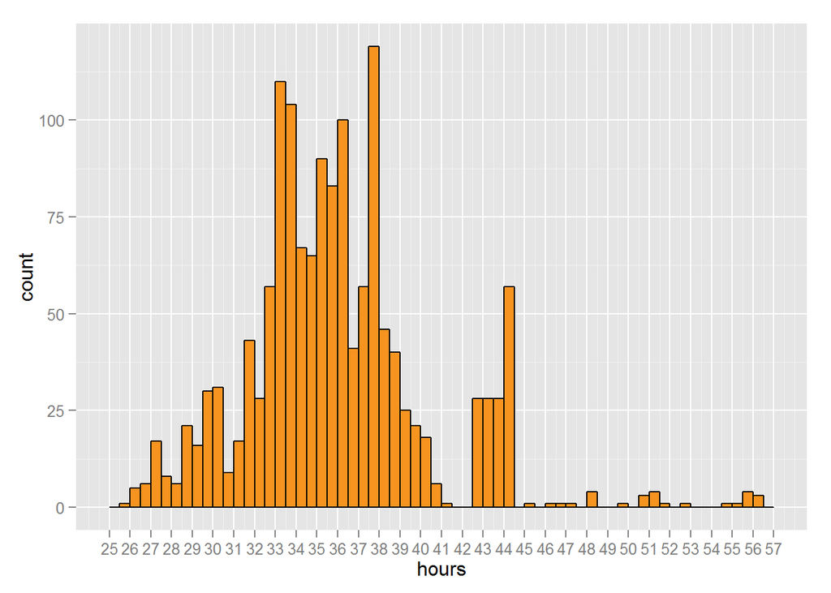

```r
ggplot(aes(x = value), data = workhours) +
  geom_histogram(binwidth = .5,  color = 'black',fill = '#F79420') +
  xlab('hours') +
  scale_x_continuous(limits = c(25, 57), breaks = seq(25, 57, 1))
```

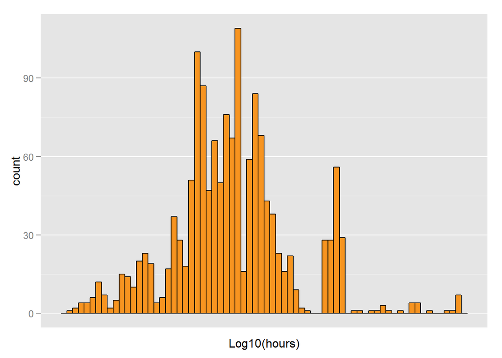

```r
ggplot(aes(x = value), data = workhours) +
  geom_histogram(binwidth = .005,  color = 'black',fill = '#F79420') +
  scale_x_log10()+
  xlab('Log10(hours)')
```

It doesn’t look like the log10 scale data is helping us at all. This is not suprising from the original distribution.

It does look like we have some points of discontinuity. Let’s zoom in on that.

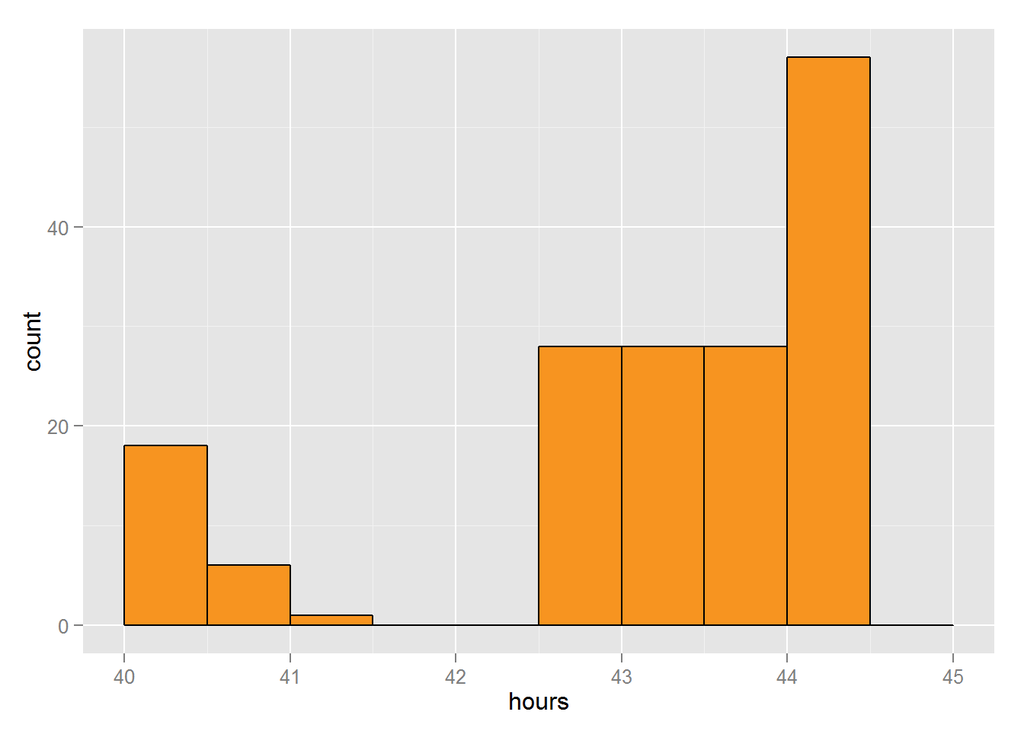

```r
ggplot(aes(x = value), data = workhours) +
  geom_histogram(binwidth = .5,  color = 'black',fill = '#F79420') +
  xlab('hours') +
  scale_x_continuous(limits = c(40, 45), breaks = seq(40, 45, 1))
```

For the years measured (1980 - 2007) no country worked 41.5 to 42.5 hours. It looks like no country worked below 25.5 or above 56.5 hours or the years given. The largest bin is 37.5 - 38 hours. The bulk of the data lies between 31.5 and 40 hours. This all makes sense given the traditional 40 hour work-week in many nations.

[figure not shown]

```r
ggplot(aes(x = value), data = workhours) +
  geom_histogram(binwidth = .5,  color = 'black',fill = '#F79420') +
  xlab('hours') +
  scale_x_continuous(limits = c(25, 57), breaks = seq(25, 57, 1)) +
  facet_wrap(~country, ncol = 1, scales = 'free')
```

## Subset Data

```r
lower = subset(workhours,value < 30)
upper = subset(workhours,value >42 )
```

I think I want to know who works 50 hours or more.

```r
over50 = subset(workhours,value >= 50)
```

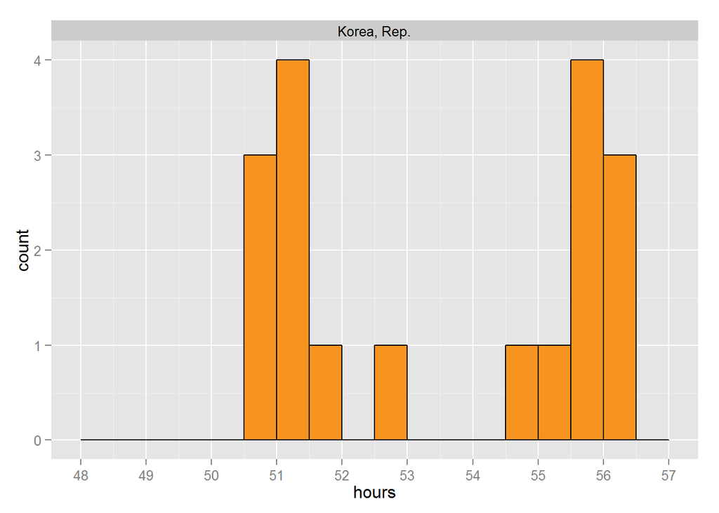

```r
ggplot(aes(x = value), data = over50) +
  geom_histogram(binwidth = .5,  color = 'black',fill = '#F79420') +
  xlab('hours') +
  scale_x_continuous(limits = c(48, 57), breaks = seq(48, 57, 1)) +
  facet_wrap(~country, ncol = 1, scales = 'free')
```

So it is just Korea, the above is the plot of all 18 years. I need to break the set into country and years.

**Breaking into years and country:**

```r
yearsmin = by(workhours$value, workhours$year, min)
yearsmin
```

```
## workhours$year: 1980
## [1] 27.27106
## --------------------------------------------------------
## workhours$year: 1981
## [1] 27.27106
## --------------------------------------------------------
## workhours$year: 1982
## [1] 27.27106
## --------------------------------------------------------
## workhours$year: 1983
## [1] 27.27106
## --------------------------------------------------------
## workhours$year: 1984
## [1] 27.27106
## --------------------------------------------------------
## workhours$year: 1985
## [1] 27.27106
## --------------------------------------------------------
## workhours$year: 1986
## [1] 27.27106
## --------------------------------------------------------
## workhours$year: 1987
## [1] 28.64751
## --------------------------------------------------------
## workhours$year: 1988
## [1] 28.64751
## --------------------------------------------------------
## workhours$year: 1989
## [1] 28.64751
## --------------------------------------------------------
## workhours$year: 1990
## [1] 28.64751
## --------------------------------------------------------
## workhours$year: 1991
## [1] 28.28846
## --------------------------------------------------------
## workhours$year: 1992
## [1] 27.82692
## --------------------------------------------------------
## workhours$year: 1993
```

[output cut: 28 more lines]

```
## --------------------------------------------------------
## workhours$year: 2003
## [1] 26.21154
## --------------------------------------------------------
## workhours$year: 2004
## [1] 26.19231
## --------------------------------------------------------
## workhours$year: 2005
## [1] 26.44231
## --------------------------------------------------------
## workhours$year: 2006
## [1] 26.75
## --------------------------------------------------------
## workhours$year: 2007
## [1] 26.76923
```

```r
yearsmax = by(workhours$value, workhours$year,max)
yearsmax
```

```
## workhours$year: 1980
## [1] 55.30769
## --------------------------------------------------------
## workhours$year: 1981
## [1] 55.61538
## --------------------------------------------------------
## workhours$year: 1982
## [1] 55.86538
## --------------------------------------------------------
## workhours$year: 1983
## [1] 56.21154
## --------------------------------------------------------
## workhours$year: 1984
## [1] 56.13462
## --------------------------------------------------------
## workhours$year: 1985
## [1] 55.65385
## --------------------------------------------------------
## workhours$year: 1986
## [1] 56.21154
## --------------------------------------------------------
## workhours$year: 1987
## [1] 55.61538
## --------------------------------------------------------
## workhours$year: 1988
## [1] 54.73077
## --------------------------------------------------------
## workhours$year: 1989
## [1] 52.73077
## --------------------------------------------------------
## workhours$year: 1990
## [1] 51.69231
## --------------------------------------------------------
## workhours$year: 1991
## [1] 51.38462
## --------------------------------------------------------
## workhours$year: 1992
## [1] 50.96154
## --------------------------------------------------------
## workhours$year: 1993
```

[output cut: 28 more lines]

```
## --------------------------------------------------------
## workhours$year: 2003
## [1] 46.80769
## --------------------------------------------------------
## workhours$year: 2004
## [1] 46.03846
## --------------------------------------------------------
## workhours$year: 2005
## [1] 45.26539
## --------------------------------------------------------
## workhours$year: 2006
## [1] 44.32692
## --------------------------------------------------------
## workhours$year: 2007
## [1] 51.29188
```

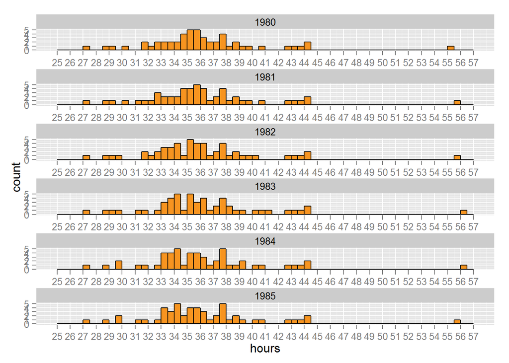

```r
ggplot(aes(x = value), data = subset(workhours, year <=1985) ) +
  geom_histogram(binwidth = .5,  color = 'black',fill = '#F79420') +
  xlab('hours') +
  scale_x_continuous(limits = c(25, 57), breaks = seq(25, 57, 1)) +
  facet_wrap(~year, ncol = 1, scales = 'free')
```

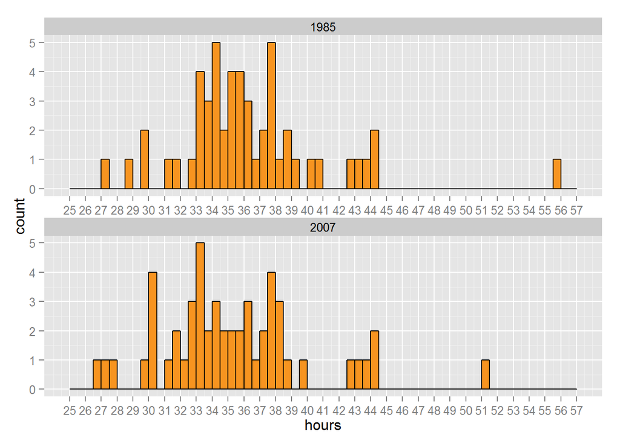

```r
ggplot(aes(x = value), data = subset(workhours, year == 1985 | year == 2007) ) +
  geom_histogram(binwidth = .5,  color = 'black',fill = '#F79420') +
  xlab('hours') +
  scale_x_continuous(limits = c(25, 57), breaks = seq(25, 57, 1)) +
  facet_wrap(~year, ncol = 1, scales = 'free')
```

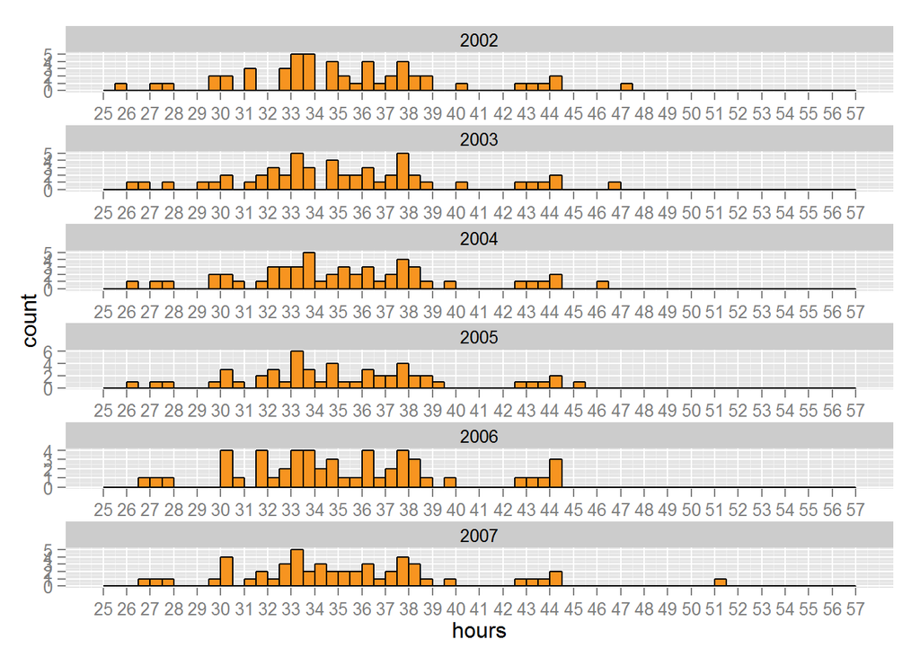

```r
ggplot(aes(x = value), data = subset(workhours, year >2001) ) +
  geom_histogram(binwidth = .5,  color = 'black',fill = '#F79420') +
  xlab('hours') +
  scale_x_continuous(limits = c(25, 57), breaks = seq(25, 57, 1)) +
  facet_wrap(~year, ncol = 1, scales = 'free')
```

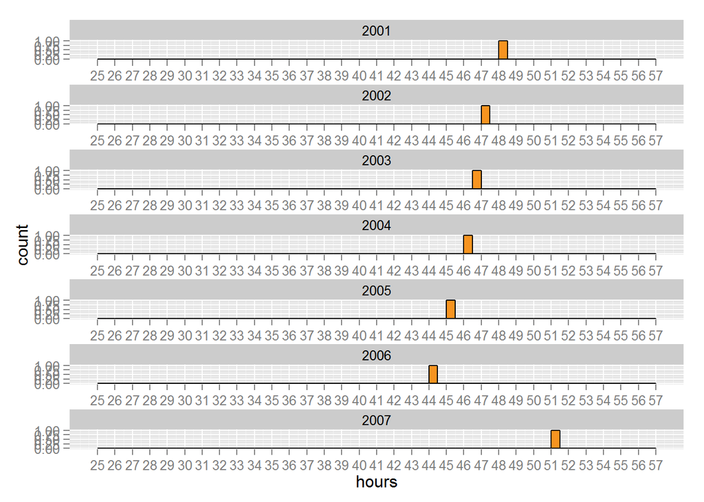

```r
ggplot(aes(x = value), data = subset(workhours, country == 'Korea, Rep.' & year > 2000) ) +
  geom_histogram(binwidth = .5,  color = 'black',fill = '#F79420') +
  xlab('hours') +
  scale_x_continuous(limits = c(25, 57), breaks = seq(25, 57, 1)) +
  facet_wrap(~year, ncol = 1, scales = 'free')
```

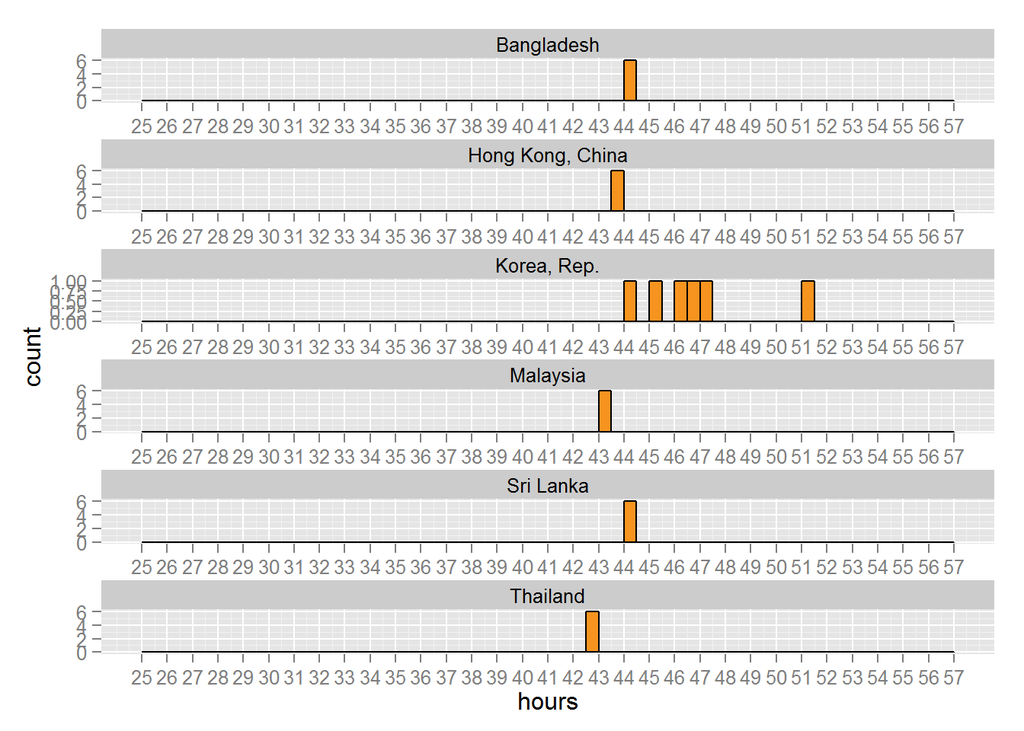

```r
ggplot(aes(x = value), data = subset(upper, year >2001) ) +
  geom_histogram(binwidth = .5,  color = 'black',fill = '#F79420') +
  xlab('hours') +
  scale_x_continuous(limits = c(25, 57), breaks = seq(25, 57, 1)) +
  facet_wrap(~country, ncol = 1, scales = 'free')
```

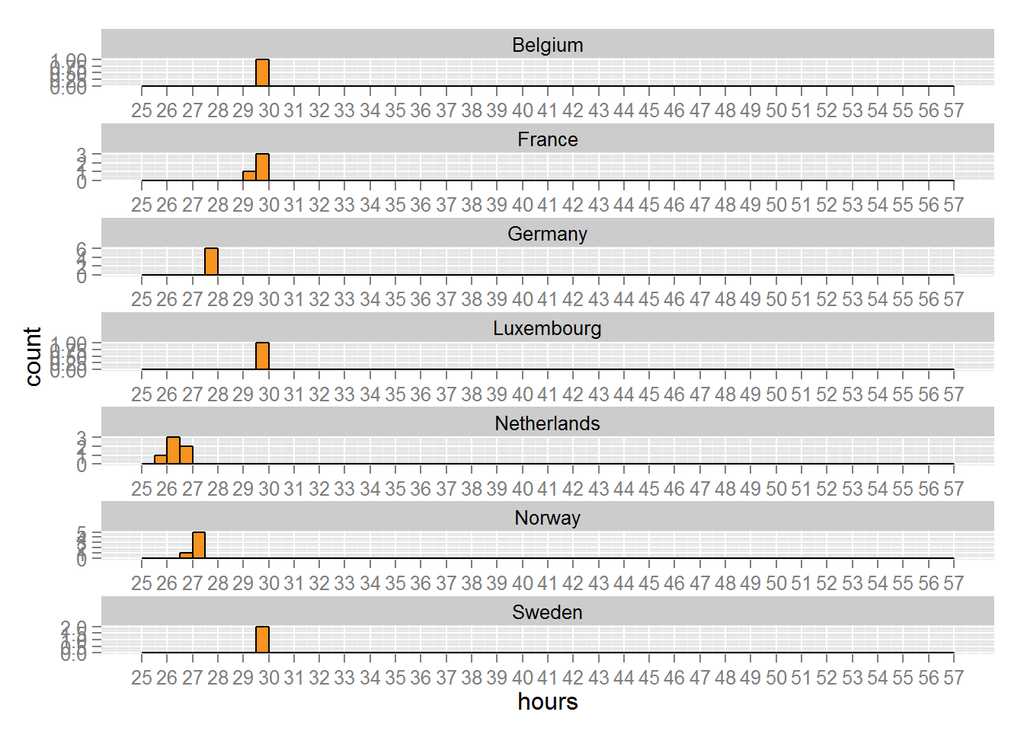

```r
ggplot(aes(x = value), data = subset(lower, year >2001) ) +
  geom_histogram(binwidth = .5,  color = 'black',fill = '#F79420') +
  xlab('hours') +
  scale_x_continuous(limits = c(25, 57), breaks = seq(25, 57, 1)) +
  facet_wrap(~country, ncol = 1, scales = 'free')
```

Compare to US:

```r
upperandUS = subset(workhours,value  >42 | country == 'United States')
lowerandUS = subset(workhours,value  <30 | country == 'United States')
```

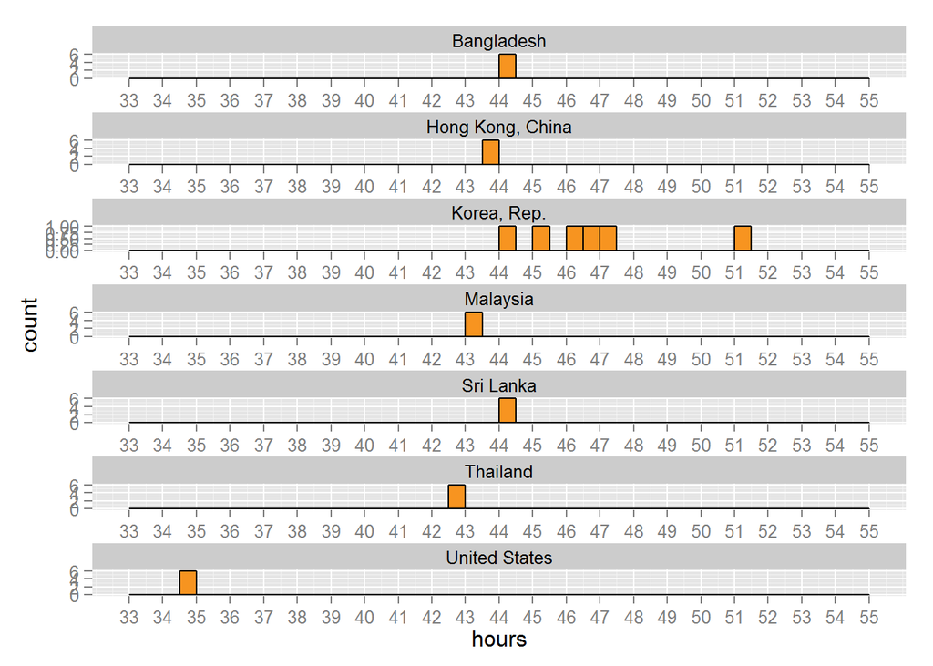

```r
ggplot(aes(x = value), data = subset(upperandUS, year >2001) ) +
  geom_histogram(binwidth = .5,  color = 'black',fill = '#F79420') +
  xlab('hours') +
  scale_x_continuous(limits = c(33, 55), breaks = seq(33, 55, 1)) +
  facet_wrap(~country, ncol = 1, scales = 'free')
```

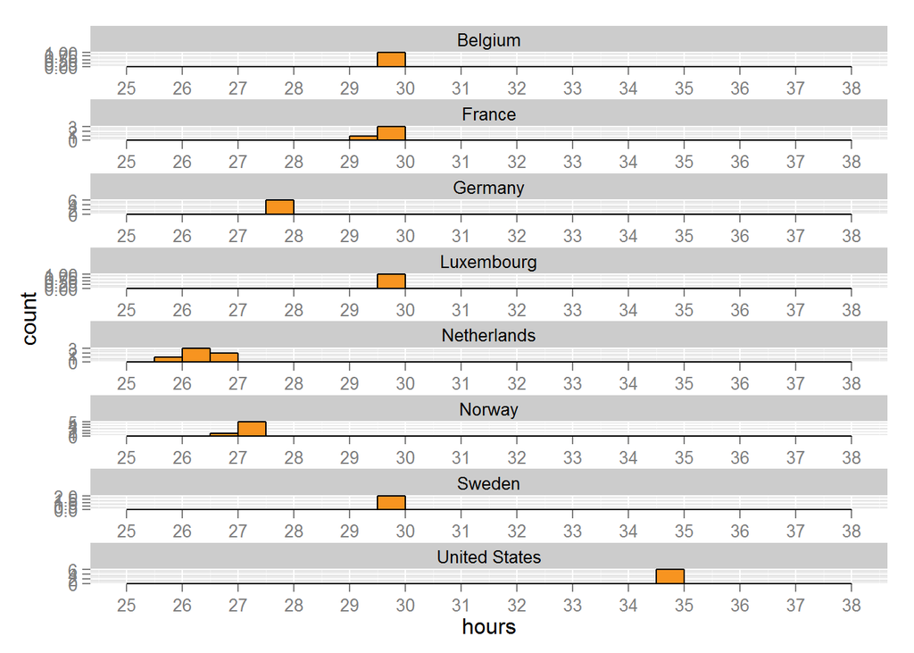

```r
ggplot(aes(x = value), data = subset(lowerandUS, year >2001) ) +
  geom_histogram(binwidth = .5,  color = 'black',fill = '#F79420') +
  xlab('hours') +
  scale_x_continuous(limits = c(25, 38), breaks = seq(25, 38 , 1)) +
  facet_wrap(~country, ncol = 1, scales = 'free')
```

**Now Let’s Try Box Plots**

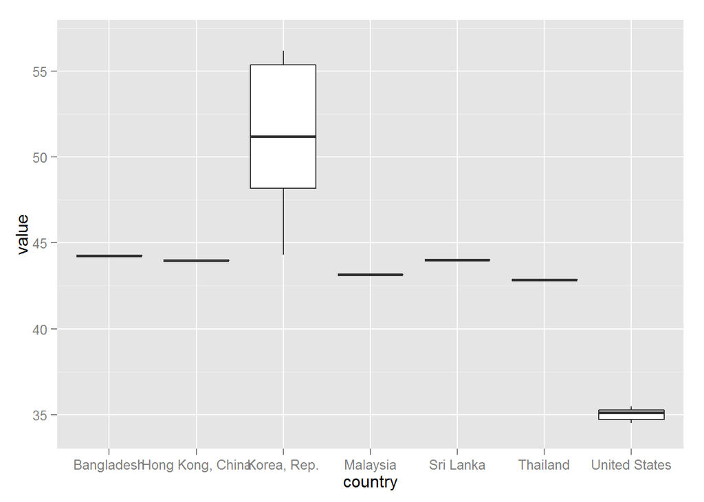

```r
qplot(x = country, y = value,data = upperandUS,geom = 'boxplot') +
  coord_cartesian(ylim=c(33,58))
```

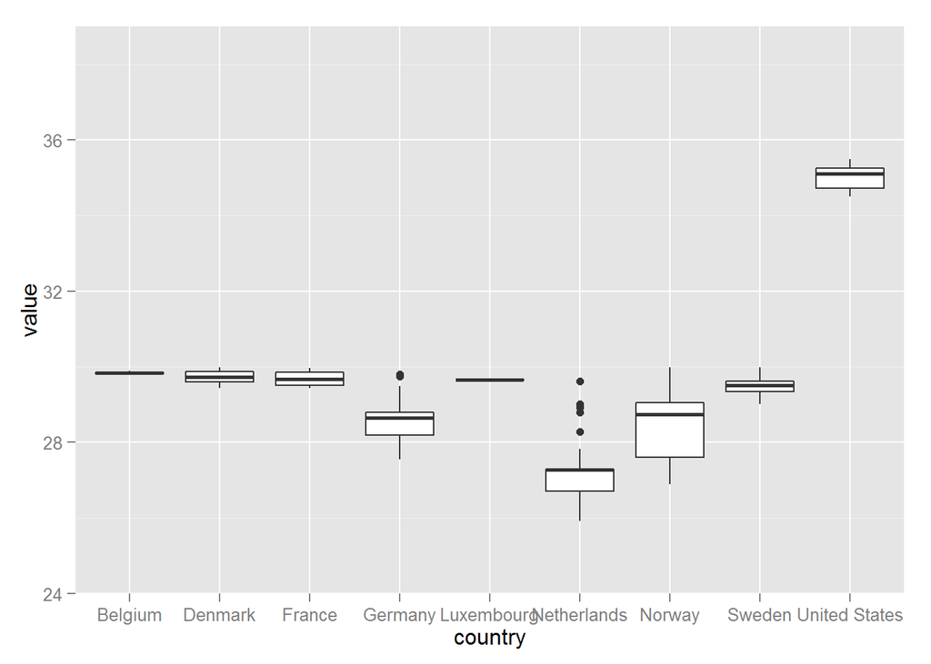

```r
qplot(x = country, y = value,data = lowerandUS,geom = 'boxplot') +
  coord_cartesian(ylim=c(24,39))
```